# python automobile project

## python project on automobile

```python
import numpy as np
import pandas as pd
import seaborn as sns
import matplotlib.pyplot as plt
```

```python
df=pd.read_csv('automobile_data.csv')
pd.set_option('display.max_columns',None)
```

```python
df
```

|  | symboling | normalized-losses | make | fuel-type | aspiration | num-of-doors | body-style | drive-wheels | engine-location | wheel-base | length | width | height | curb-weight | engine-type | num-of-cylinders | engine-size | fuel-system | bore | stroke | compression-ratio | horsepower | peak-rpm | city-mpg | highway-mpg | price |
| --- | --- | --- | --- | --- | --- | --- | --- | --- | --- | --- | --- | --- | --- | --- | --- | --- | --- | --- | --- | --- | --- | --- | --- | --- | --- | --- |
| 0 | 3 | 122 | alfa-romero | gas | std | two | convertible | rwd | front | 88.6 | 168.8 | 64.1 | 48.8 | 2548 | dohc | four | 130 | mpfi | 3.47 | 2.68 | 9.0 | 111 | 5000 | 21 | 27 | 13495 |
| 1 | 3 | 122 | alfa-romero | gas | std | two | convertible | rwd | front | 88.6 | 168.8 | 64.1 | 48.8 | 2548 | dohc | four | 130 | mpfi | 3.47 | 2.68 | 9.0 | 111 | 5000 | 21 | 27 | 16500 |
| 2 | 1 | 122 | alfa-romero | gas | std | two | hatchback | rwd | front | 94.5 | 171.2 | 65.5 | 52.4 | 2823 | ohcv | six | 152 | mpfi | 2.68 | 3.47 | 9.0 | 154 | 5000 | 19 | 26 | 16500 |
| 3 | 2 | 164 | audi | gas | std | four | sedan | fwd | front | 99.8 | 176.6 | 66.2 | 54.3 | 2337 | ohc | four | 109 | mpfi | 3.19 | 3.4 | 10.0 | 102 | 5500 | 24 | 30 | 13950 |
| 4 | 2 | 164 | audi | gas | std | four | sedan | 4wd | front | 99.4 | 176.6 | 66.4 | 54.3 | 2824 | ohc | five | 136 | mpfi | 3.19 | 3.4 | 8.0 | 115 | 5500 | 18 | 22 | 17450 |
| ... | ... | ... | ... | ... | ... | ... | ... | ... | ... | ... | ... | ... | ... | ... | ... | ... | ... | ... | ... | ... | ... | ... | ... | ... | ... | ... |
| 200 | -1 | 95 | volvo | gas | std | four | sedan | rwd | front | 109.1 | 188.8 | 68.9 | 55.5 | 2952 | ohc | four | 141 | mpfi | 3.78 | 3.15 | 9.5 | 114 | 5400 | 23 | 28 | 16845 |
| 201 | -1 | 95 | volvo | gas | turbo | four | sedan | rwd | front | 109.1 | 188.8 | 68.8 | 55.5 | 3049 | ohc | four | 141 | mpfi | 3.78 | 3.15 | 8.7 | 160 | 5300 | 19 | 25 | 19045 |
| 202 | -1 | 95 | volvo | gas | std | four | sedan | rwd | front | 109.1 | 188.8 | 68.9 | 55.5 | 3012 | ohcv | six | 173 | mpfi | 3.58 | 2.87 | 8.8 | 134 | 5500 | 18 | 23 | 21485 |
| 203 | -1 | 95 | volvo | diesel | turbo | four | sedan | rwd | front | 109.1 | 188.8 | 68.9 | 55.5 | 3217 | ohc | six | 145 | idi | 3.01 | 3.4 | 23.0 | 106 | 4800 | 26 | 27 | 22470 |
| 204 | -1 | 95 | volvo | gas | turbo | four | sedan | rwd | front | 109.1 | 188.8 | 68.9 | 55.5 | 3062 | ohc | four | 141 | mpfi | 3.78 | 3.15 | 9.5 | 114 | 5400 | 19 | 25 | 22625 |

205 rows × 26 columns

```python
# Data collection
```

1] "symboling" refers to the insurance risk level assigned to a car, adjusted based on its perceived danger. It's a numerical code, typically ranging from -3 (very safe) to +3 (very risky), used by insurance companies to determine premiums. Symboling Number Risk Level -3 Very Low Risk (Safest) -2 Low Risk -1 Slightly Low Risk 0 Medium / Average Risk +1 Slightly High Risk +2 High Risk +3 Very High Risk 2]. "normalized-losses" It represents the relative average loss payment per insured vehicle. Basically, it's a measure of how much money insurance companies lose on a specific car relative to other cars. Value Range Risk Level Insurance Cost Benefit Below 100 Low risk Lower premiums ✅ High Around 100 Average risk Standard premiums ➖ Moderate Above 100 High risk Higher premium ❌ Low 3]."make" It’s the company that produced the vehicle. For example: Toyota, BMW, honda, audi, chevrolet, etc. 4]."fuel-type" The fuel-type column tells you what kind of fuel the car uses. Factor Gas Diesel Fuel Efficiency Moderate Higher Maintenance Cost Lower Higher Engine Life Shorter Longer Emissions Higher CO2 More NOx/particles Fuel Cost Usually cheaper Sometimes cheaper Performance More horsepower More torque 5]."aspiration" It describes how the air enters the engine for combustion, and there are typically two types: Aspiration Type Description std Standard aspiration — The engine uses atmospheric pressure to draw in air. It doesn’t have a turbocharger or supercharger. turbo Turbocharged aspiration — The engine has a turbocharger, which forces additional air into the engine for better performance and power. 6]."num_of_door" It tells you how many doors the car has for passengers to enter and exit. Typically, you’ll see values like: num-of-doors Car Type 2 Typically a coupe or sports car 4 Usually a sedan, SUV, or hatchback 7]. "body-style" The body-style column classifies the car based on its shape and layout. Common values include: Body Style Description convertible A car with a removable or retractable roof. Usually sportier, with 2 doors. hatchback A car with a rear hatch door that opens upwards, often with foldable seats. sedan A 4-door car with a separate trunk. Common for family or everyday use. wagon Similar to a sedan but with a longer roofline and more trunk space. hardtop A car with no roof pillars between windows and no B-pillar (supports the door). pickup A vehicle with an open cargo area (often in the rear), typically with 2 doors or 4 doors. 8]. "drive-wheels" Common values for drive-wheels include: Drive-Wheel Type Description fwd (Front-Wheel Drive) Power is delivered to the front wheels, which are responsible for both steering and moving the car. This is common in compact cars. rwd (Rear-Wheel Drive) Power is delivered to the rear wheels. This is common in performance cars and trucks. 4wd (Four-Wheel Drive) Power is distributed to all four wheels, which is useful for off-roading and rough terrains. Typically found in SUVs or trucks. awd (All-Wheel Drive) Power is automatically distributed to all four wheels as needed, but it is usually for on-road conditions. Common in crossovers and some SUVs. 9]."engine-location" There are typically two types of engine locations: Engine Location Description front The engine is located in the front of the vehicle, usually in front of the passenger cabin. This is the most common engine placement. rear The engine is located in the rear of the vehicle, typically behind the rear axle. This setup is less common and often found in performance cars or sports cars. 10]."wheel-base" The wheelbase is the horizontal distance between the center of the front wheels and the center of the rear wheels. It's usually measured in inches or millimeters. Wheelbase Best For Key Benefit Drawback Longer Wheelbase High-speed stability, comfort More stability, better ride comfort Less maneuverability, bulkier Shorter Wheelbase Sports cars, city driving More agile, better fuel efficiency Less stability, rougher ride 11]. "lenght" The length of a vehicle refers to its overall size from the front bumper to the rear bumper. It is typically measured in inches or millimeters and is an important metric that can influence the vehicle's performance, handling, comfort, and aesthetic appeal. Length Best For Key Benefit Drawback Longer Length Family use, luxury cars, SUVs More space, better high-speed stability Less maneuverable, higher fuel consumption Shorter Length Sports cars, city cars Better maneuverability, fuel efficiency Less space, less high-speed stability 12]."width" The width of a vehicle refers to its overall width from one side to the other, typically measured at the widest part of the car, excluding mirrors. It is usually measured in inches or millimeters and has an impact on a vehicle’s aesthetic appeal, handling, stability, and interior space. Width Best For Key Benefit Drawback Wider Vehicles SUVs, performance cars, luxury carsBetter stability, more interior space Less maneuverable, lower fuel efficiency Narrower Vehicles Compact cars, city cars Better fuel efficiency, more agile Less stability, less interior space 13]. "height" In the Automobile dataset, the height feature refers to the total vertical measurement of the vehicle — from the lowest point (typically the ground) to the highest point (often the roof). It is usually measured in inches or millimeters. Height Best For Benefits Drawbacks Taller Height SUVs, crossovers, family cars More interior space, better visibility Less stable, lower fuel efficiency Shorter Height Sports cars, sedans, city cars Better handling, fuel-efficient, stable Less comfort/headroom, lower visibility 14]. " curb-weight" In the Automobile dataset, curb-weight refers to the total weight of a vehicle without passengers or cargo, but with all standard equipment, necessary fluids (like oil and coolant), and a full tank of fuel. Curb Weight Best For Pros Cons High Curb Weight SUVs, luxury cars Safer, more stable, more features Lower mileage, more expensive to maintain Low Curb Weight Compact, sports, eco cars Fuel efficient, faster, eco-friendly Less protection, fewer comfort feature Curb Weight Range (lbs) Vehicle Type Benefit Risk/Trade-off < 2,000 lbs Mini/Compact cars (e.g. Smart Car) Excellent fuel economy, nimble handling Low safety, less space 2,000 – 2,500 lbs Small hatchbacks, city cars Good efficiency, easy to drive Moderate stability and safety 2,500 – 3,000 lbs Sedans, coupes Balanced performance and fuel economy Common range; moderate pros and cons 3,000 – 3,500 lbs Midsize sedans, compact SUVs Comfortable, safer, more features Slight drop in mileage 3,500 – 4,000 lbs Full-size sedans, SUVs Safer, smoother ride, family-friendly Lower fuel efficiency 4,000 – 5,000+ lbs Luxury SUVs, Trucks Very safe, durable, feature-loaded High fuel usage, expensive maintenance 15]."engine-type" the engine-type feature refers to the design or configuration of the engine — essentially, how the engine is built and how it operates internally. Different engine types affect a car's performance, fuel efficiency, cost, and maintenance. Engine Type Description Common In Benefit .dohc Double Overhead Camshaft – 2 camshafts for better valve control Performance & modern cars More power, better high-RPM performance .ohcv Overhead Valve, with vertical camshaft and valves Trucks, older models Simpler design, strong torque .ohc Overhead Camshaft – 1 camshaft in cylinder head Most standard cars Good balance of efficiency and .power .l Inline engine (may refer to layout, often with "ohc") Compact cars Efficient and simple .rotor Rotary engine (Wankel engine, rare) Mazda RX series Lightweight, high-revving .dohcv double Overhead Camshaft with 4 valves/cylinder (advanced version of dohc) Sports & luxury cars Best performance, very efficient at high RPM .ohcf Overhead Camshaft Forward-facing (specific variation of OHC) Some European cars Compact and efficient 16]."num-of-cylinders" the num-of-cylinders feature represents the number of cylinders in a car's engine — a key factor affecting the power, efficiency, and smoothness of the engine. Number of Cylinders Typically Seen In Power Level Fuel Efficiency Cost 3 cylinders Small economy cars Low Very High Very Low 4 cylinders Most compact and midsize cars Moderate High Affordable 5 cylinders Some European cars (rare) Good Moderate Moderate 6 cylinders Performance sedans, crossovers High Medium Higher 8 cylinders Sports cars, trucks, muscle cars Very High Low Expensive 12 cylinders Luxury sports cars (e.g., Ferrari) Extreme Very Low Very Expensive 17]."engine-size" engine-size refers to the total volume (displacement) of all the engine’s cylinders combined, usually measured in cubic centimeters (cc). Number Meaning (Approx) Equivalent Real-world Type 61 Very small engine 0.6L Small bike or tiny car 122 Small car engine 1.2L Maruti Alto, Hyundai Eon 209 Mid-size car engine 2.0L honda Civic, Toyota Corolla 326 Large/powerful engine 3.2L SUVs or sports cars 18]."fuel-system" The fuel system in a car is responsible for storing and delivering fuel to the engine for combustion. In the automobile dataset, the fuel-system Fuel System Meaning Used In mpfi Multi-Point Fuel Injection – injects fuel into each cylinder separately Modern fuel-efficient cars 2bbl 2-Barrel Carburetor – older system, two barrels control air-fuel mix Older cars 1bbl 1-Barrel Carburetor – even older, single fuel-air mixing chamber Very old or low-power cars spdi Single Point Direct Injection – injects fuel at one point Entry-level fuel injection spfi Single Point Fuel Injection – similar to spdi, single injector Small engines 4bbl 4-Barrel Carburetor – higher fuel flow, more power Muscle cars or trucks idi Indirect Diesel Injection – used in diesel engines, fuel preheated Diesel cars mfi Mechanical Fuel Injection – older injection system Vintage performance cars 19]."bore" Bore refers to the diameter of a cylinder inside the engine — specifically, the circular opening where the piston moves up and down. Bore Size (in inches) What It Means for the Engine Common In 2.5 in or less Small cylinder → lower power → better mileage Compact cars, small engines 2.6 - 3.0 in Balanced mix of power and efficiency Sedans, hatchbacks 3.1 - 3.5 in Bigger cylinders → more horsepower → moderate fuel usage SUVs, performance sedans 3.6 in or more High-performance engine → more power → more fuel needed Sports cars, trucks, V8s 20]."stroke" the term stroke refers to the movement of the piston within the cylinder of an internal combustion engine. It is a fundamental concept related to how engines generate power. 21]."compression-ratio " The compression ratio is a key parameter in internal combustion engines that significantly influences engine performance, efficiency, and emissions. It is defined as the ratio of the volume of the cylinder when the piston is at the bottom dead center (BDC) to the volume when the piston is at the top dead center (TDC). Compression Ratio Formula: Compression Ratio = Volume at BDC Volume at TDC Compression Ratio= Volume at TDC Volume at BDC  Higher Compression Ratio (e.g., 12:1, 13:1),,Lower Compression Ratio (e.g., 8:1, 9:1): 22]."horsepower"Horsepower is a unit of measurement used to express the power output of an engine, motor, or machine. It quantifies how much work is done over time, specifically how fast an engine can perform work. Horsepower (hp)= 5252 Torque (lb-ft)×RPM  Low Horsepower (less than 100 hp): These values are generally found in small economy cars, compact cars, or entry-level vehicles. These engines focus on fuel efficiency rather than performance. Moderate Horsepower (100-200 hp): These are typically found in mid-range vehicles like sedans, SUVs, and light trucks. These vehicles balance power and fuel efficiency. High Horsepower (200+ hp): Engines in this range are typically found in sports cars, muscle cars, performance vehicles, and light trucks designed for towing or heavy-duty tasks. 23]."peak-rpm" Peak RPM is the maximum rotational speed of an engine's crankshaft, at which it delivers the most power or torque. This is typically indicated by the engine manufacturer and is one of the key characteristics in tuning or designing engines for performance. **Low RPM (Idle to 2,000 RPM): Description: This range typically represents when the engine is idling or driving at very low speeds (e.g., starting from a stop). Performance Impact: Engines produce very little power at low RPM. However, fuel efficiency is higher since the engine is not working hard. Example: At idle, the RPM could be around 600-1,000 RPM. In this state, the engine is running but not producing significant power. **Medium RPM (2,000 to 4,000 RPM): Description: In this range, the engine is producing more power, and the car can accelerate smoothly without the engine being under heavy strain. Performance Impact: The engine is able to provide enough torque and power to drive at city or highway speeds efficiently. It’s the "sweet spot" for daily driving in most cases. Example: When cruising on the highway at a steady speed, your RPM may be around 2,000-3,000 RPM for a comfortable, efficient ride. **High RPM (4,000 to 7,000 RPM): Description: Engines can rev into this range under heavy acceleration, such as during overtaking or driving in sports modes. Performance Impact: Higher RPMs mean the engine is generating more power. However, efficiency decreases, and fuel consumption increases as the engine requires more fuel to maintain higher speeds. Example: Performance vehicles like sports cars or muscle cars often peak their power in this range (e.g., 5,000-7,000 RPM). **Redline (7,000 to 10,000+ RPM): Description: This is the maximum RPM the engine can reach before damage occurs (indicated by a redline on the tachometer). Performance Impact: At this point, the engine has reached its peak power output, but it is unsafe to continue operating the engine beyond this limit. The engine may lose efficiency, and parts could suffer from excessive wear or failure if over-revved. Example: Racing engines or high-performance cars may be designed to operate safely in the 8,000-10,000 RPM range. 24]."city-mpg" City MPG (Miles Per Gallon) refers to the number of miles a vehicle can travel on one gallon of fuel when driving in urban or city conditions, where frequent stops, starts, and slower speeds are typical. It is a key indicator of a vehicle’s fuel efficiency under normal city driving conditions, which generally involve more frequent acceleration and deceleration compared to highway driving. Compact Cars: 25-40 City MPG Sedans: 20-35 City MPG SUVs: 15-25 City MPG Trucks: 15-20 City MPG Hybrid Vehicles: 40-60 City MPG 25]."highway-mpg" Highway MPG (Miles Per Gallon) refers to the number of miles a vehicle can travel on one gallon of fuel under highway driving conditions. These conditions typically involve steady speeds and fewer stops compared to city driving. Highway driving is usually more fuel-efficient because there's less acceleration and braking involved. Compact Cars: 35-45 Highway MPG Sedans: 30-40 Highway MPG Small SUVs: 25-35 Highway MPG Large SUVs and Trucks: 15-25 Highway MPG Hybrid Vehicles: 40-60 Highway MPG Electric Vehicles (EVs): Measured in MPGe (Miles Per Gallon Equivalent), typically 120-140 MPGe on the highway. 26].price Compact Cars (Fuel-efficient and Affordable) Price Range: $15,000 - $30,000 (New) Examples: Toyota Corolla: Around $20,000 - $25,000 Honda Civic: Around $22,000 - $30,000 Hyundai Elantra: Around $20,000 - $25,000 2. Sedans (Popular for Daily Commuting) Price Range: $20,000 - $50,000 (New) Examples: Toyota Camry: Around $25,000 - $35,000 Honda Accord: Around $25,000 - $35,000 BMW 3 Series: Around $41,000 - $50,000 3. Hybrid Vehicles (Great for Fuel Economy) Price Range: $20,000 - $50,000 (New) Examples: Toyota Prius: Around $25,000 - $30,000 Honda Insight: Around $23,000 - $30,000 Toyota Camry Hybrid: Around $30,000 - $35,000 4. Electric Vehicles (EVs) (Zero Emissions, High Tech) Price Range: $30,000 - $80,000 (New) Examples: Tesla Model 3: Around $40,000 - $50,000 Chevrolet Bolt EV: Around $30,000 - $35,000 Ford Mustang Mach-E: Around $45,000 - $60,000 5. SUVs (Spacious, Versatile for Families) Price Range: $20,000 - $60,000 (New) Examples: Toyota RAV4: Around $27,000 - $35,000 Honda CR-V: Around $28,000 - $36,000 Ford Escape: Around $26,000 - $35,000 Jeep Grand Cherokee: Around $40,000 - $55,000 6. Full-Size Trucks (For Heavy-Duty and Towing) Price Range: $30,000 - $75,000 (New) Examples: Ford F-150: Around $33,000 - $70,000 Chevrolet Silverado: Around $33,000 - $55,000 Ram 1500: Around $32,000 - $60,000 7. Luxury Vehicles (High-End Features and Performance) Price Range: $40,000 - $150,000 (New) Examples: Mercedes-Benz C-Class: Around $45,000 - $55,000 BMW 5 Series: Around $55,000 - $70,000 Audi A6: Around $55,000 - $70,000 Tesla Model S: Around $85,000 - $100,000 8. Sports Cars (Performance-Focused) Price Range: $40,000 - $200,000+ Examples: Chevrolet Corvette: Around $60,000 - $90,000 Porsche 911: Around $60,000 - $120,000 Ford Mustang GT: Around $45,000 - $60,000 Tesla Model 3 (Electric Vehicle): ~$40,000; 130 MPGe City / 130 MPGe Highway Ford F-150 (Truck): ~$35,000; 20 MPG City / 26 MPG Highway

```python
df.info()
```

```
<class 'pandas.core.frame.DataFrame'>
RangeIndex: 205 entries, 0 to 204
Data columns (total 26 columns):
 #   Column             Non-Null Count  Dtype
---  ------             --------------  -----
 0   symboling          205 non-null    int64
 1   normalized-losses  205 non-null    int64
 2   make               205 non-null    object
 3   fuel-type          205 non-null    object
 4   aspiration         205 non-null    object
 5   num-of-doors       205 non-null    object
 6   body-style         205 non-null    object
 7   drive-wheels       205 non-null    object
 8   engine-location    205 non-null    object
 9   wheel-base         205 non-null    float64
```

[output cut: 18 more lines]

```python
df.shape
```

```
(205, 26)
```

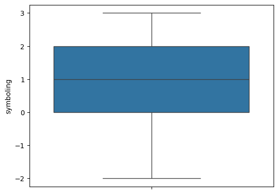

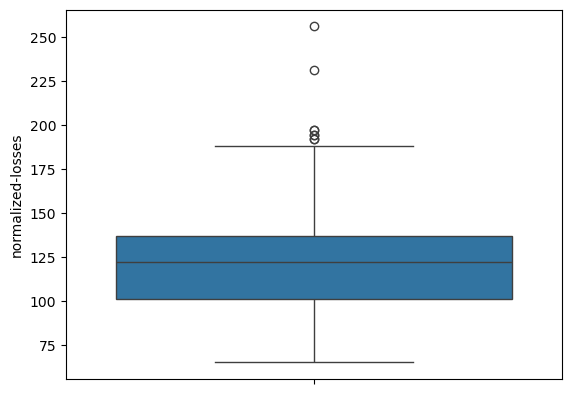

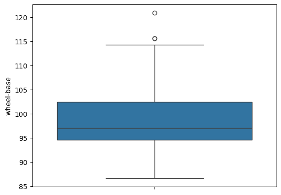

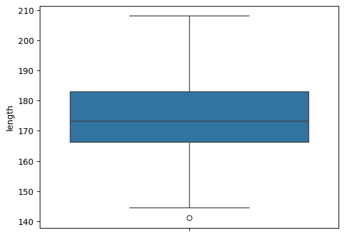

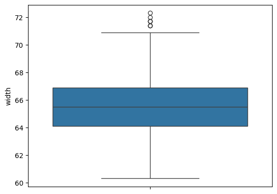

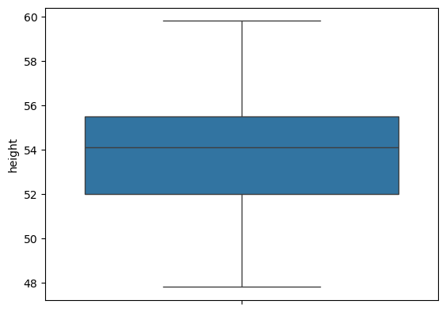

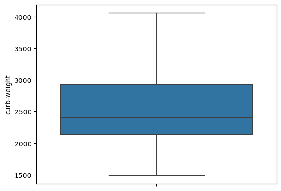

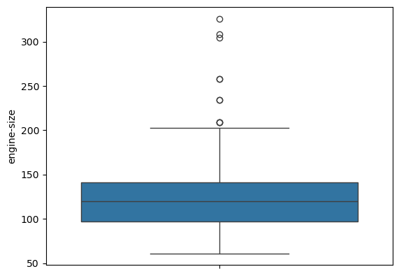

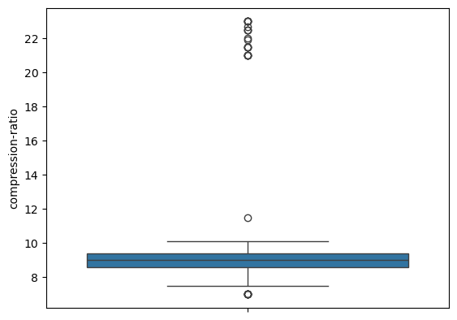

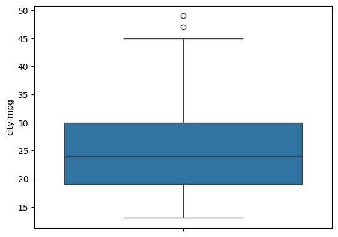

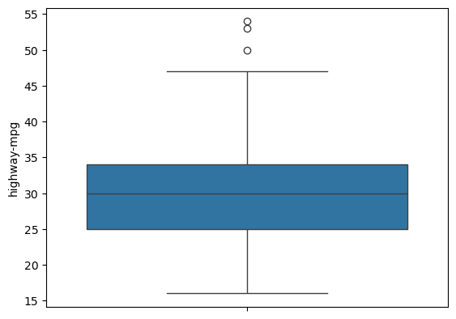

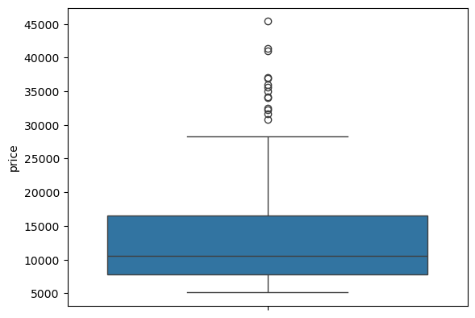

```python
# find out the outlier
col_num=df.select_dtypes(include=['int','float'])
for  column in col_num.columns:
    sns.boxplot(col_num[column])


    plt.show()
```

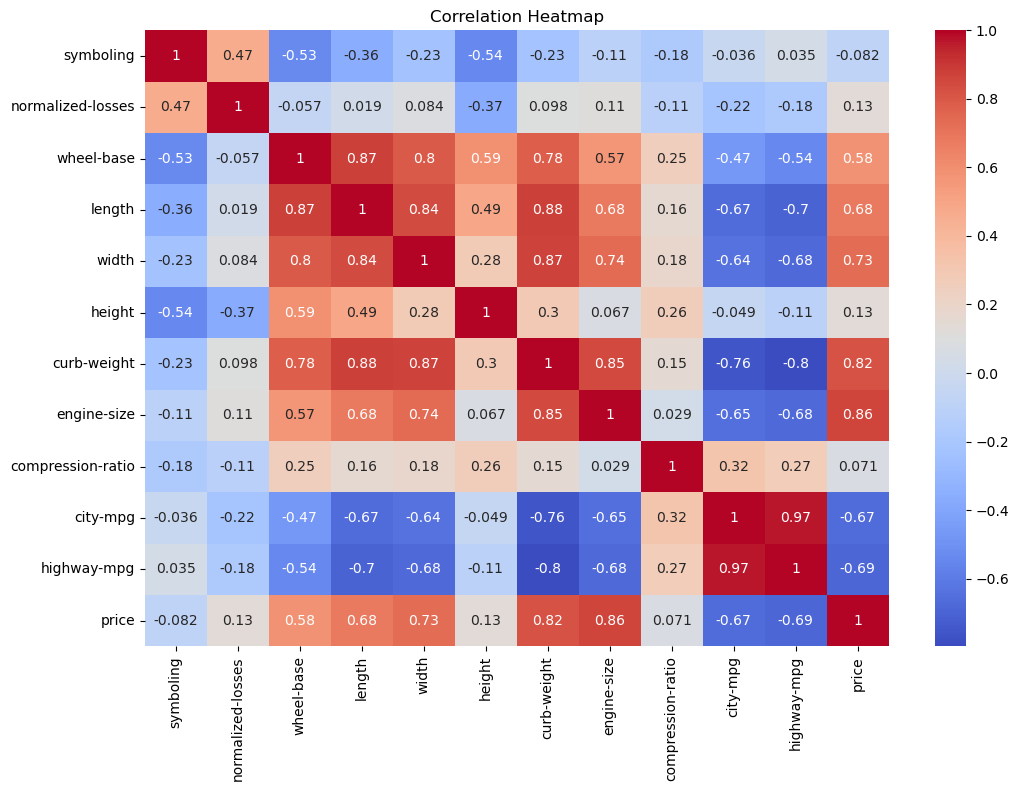

```python
import seaborn as sns
import matplotlib.pyplot as plt
df1 = df.select_dtypes(include=['int64', 'float64'])
plt.figure(figsize=(12, 8))
sns.heatmap(df1.corr(), annot=True,cmap='coolwarm')
plt.title('Correlation Heatmap')
plt.show()
```

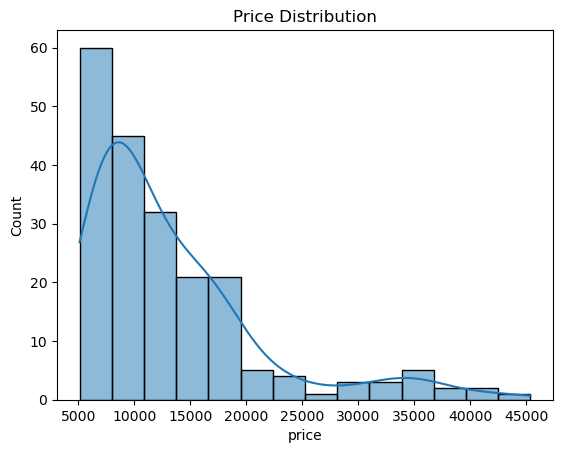

```python
sns.histplot(df['price'], kde=True)
plt.title('Price Distribution')
plt.show()
```

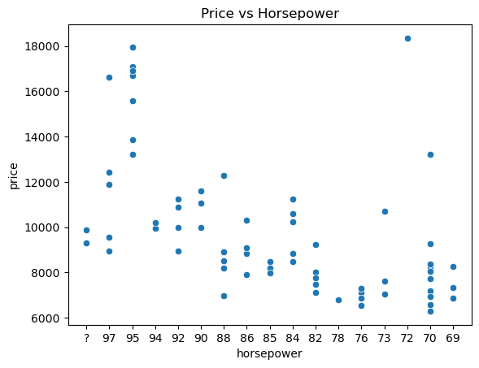

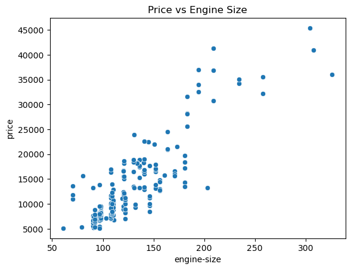

```python
top10_hp = df.sort_values(by='horsepower', ascending=False).head(70)

sns.scatterplot(x='horsepower', y='price', data=top10_hp)
plt.title('Price vs Horsepower')
plt.show()

sns.scatterplot(x='engine-size', y='price', data=df)
plt.title('Price vs Engine Size')
plt.show()
```

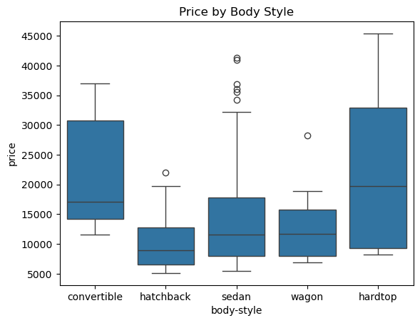

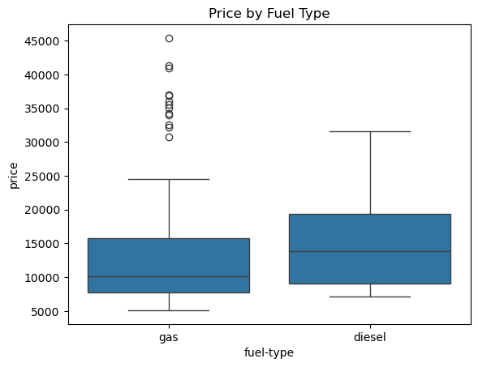

```python
sns.boxplot(x='body-style', y='price', data=df)
plt.title('Price by Body Style')

plt.show()

sns.boxplot(x='fuel-type', y='price', data=df)
plt.title('Price by Fuel Type')
plt.show()
```

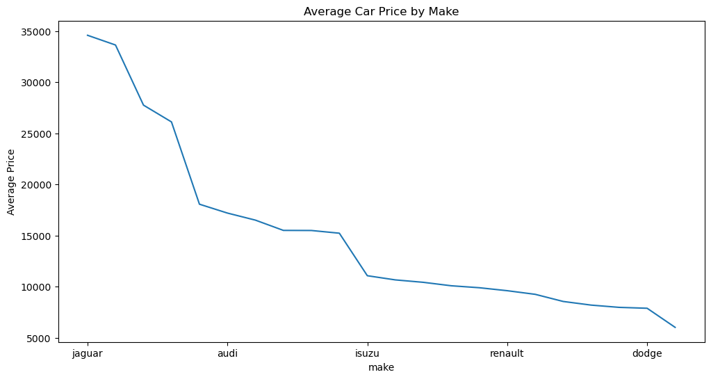

```python
avg_price = df.groupby('make')['price'].mean().sort_values(ascending=False)
avg_price.plot( figsize=(12, 6))
plt.title('Average Car Price by Make')
plt.ylabel('Average Price')
plt.show()
```

```python
df
```

|  | symboling | normalized-losses | make | fuel-type | aspiration | num-of-doors | body-style | drive-wheels | engine-location | wheel-base | length | width | height | curb-weight | engine-type | num-of-cylinders | engine-size | fuel-system | bore | stroke | compression-ratio | horsepower | peak-rpm | city-mpg | highway-mpg | price |
| --- | --- | --- | --- | --- | --- | --- | --- | --- | --- | --- | --- | --- | --- | --- | --- | --- | --- | --- | --- | --- | --- | --- | --- | --- | --- | --- |
| 0 | 3 | 122 | alfa-romero | gas | std | two | convertible | rwd | front | 88.6 | 168.8 | 64.1 | 48.8 | 2548 | dohc | four | 130 | mpfi | 3.47 | 2.68 | 9.0 | 111 | 5000 | 21 | 27 | 13495 |
| 1 | 3 | 122 | alfa-romero | gas | std | two | convertible | rwd | front | 88.6 | 168.8 | 64.1 | 48.8 | 2548 | dohc | four | 130 | mpfi | 3.47 | 2.68 | 9.0 | 111 | 5000 | 21 | 27 | 16500 |
| 2 | 1 | 122 | alfa-romero | gas | std | two | hatchback | rwd | front | 94.5 | 171.2 | 65.5 | 52.4 | 2823 | ohcv | six | 152 | mpfi | 2.68 | 3.47 | 9.0 | 154 | 5000 | 19 | 26 | 16500 |
| 3 | 2 | 164 | audi | gas | std | four | sedan | fwd | front | 99.8 | 176.6 | 66.2 | 54.3 | 2337 | ohc | four | 109 | mpfi | 3.19 | 3.4 | 10.0 | 102 | 5500 | 24 | 30 | 13950 |
| 4 | 2 | 164 | audi | gas | std | four | sedan | 4wd | front | 99.4 | 176.6 | 66.4 | 54.3 | 2824 | ohc | five | 136 | mpfi | 3.19 | 3.4 | 8.0 | 115 | 5500 | 18 | 22 | 17450 |
| ... | ... | ... | ... | ... | ... | ... | ... | ... | ... | ... | ... | ... | ... | ... | ... | ... | ... | ... | ... | ... | ... | ... | ... | ... | ... | ... |
| 200 | -1 | 95 | volvo | gas | std | four | sedan | rwd | front | 109.1 | 188.8 | 68.9 | 55.5 | 2952 | ohc | four | 141 | mpfi | 3.78 | 3.15 | 9.5 | 114 | 5400 | 23 | 28 | 16845 |
| 201 | -1 | 95 | volvo | gas | turbo | four | sedan | rwd | front | 109.1 | 188.8 | 68.8 | 55.5 | 3049 | ohc | four | 141 | mpfi | 3.78 | 3.15 | 8.7 | 160 | 5300 | 19 | 25 | 19045 |
| 202 | -1 | 95 | volvo | gas | std | four | sedan | rwd | front | 109.1 | 188.8 | 68.9 | 55.5 | 3012 | ohcv | six | 173 | mpfi | 3.58 | 2.87 | 8.8 | 134 | 5500 | 18 | 23 | 21485 |
| 203 | -1 | 95 | volvo | diesel | turbo | four | sedan | rwd | front | 109.1 | 188.8 | 68.9 | 55.5 | 3217 | ohc | six | 145 | idi | 3.01 | 3.4 | 23.0 | 106 | 4800 | 26 | 27 | 22470 |
| 204 | -1 | 95 | volvo | gas | turbo | four | sedan | rwd | front | 109.1 | 188.8 | 68.9 | 55.5 | 3062 | ohc | four | 141 | mpfi | 3.78 | 3.15 | 9.5 | 114 | 5400 | 19 | 25 | 22625 |

205 rows × 26 columns

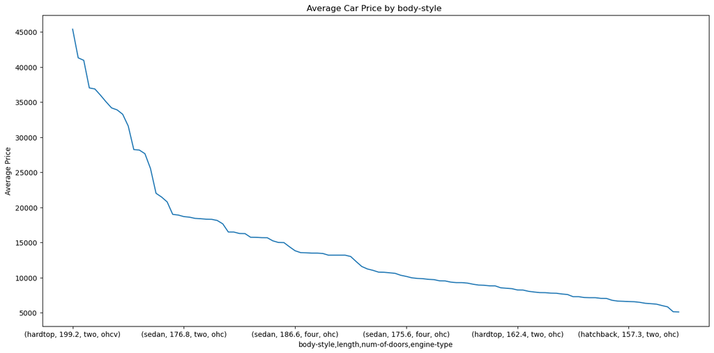

```python
avg_price=df.groupby(['body-style','length','num-of-doors','engine-type'])['price'].mean().sort_values(ascending=False)
avg_price.plot(figsize=(17,8))
plt.title('Average Car Price by body-style ')
plt.ylabel('Average Price')
plt.show()
```

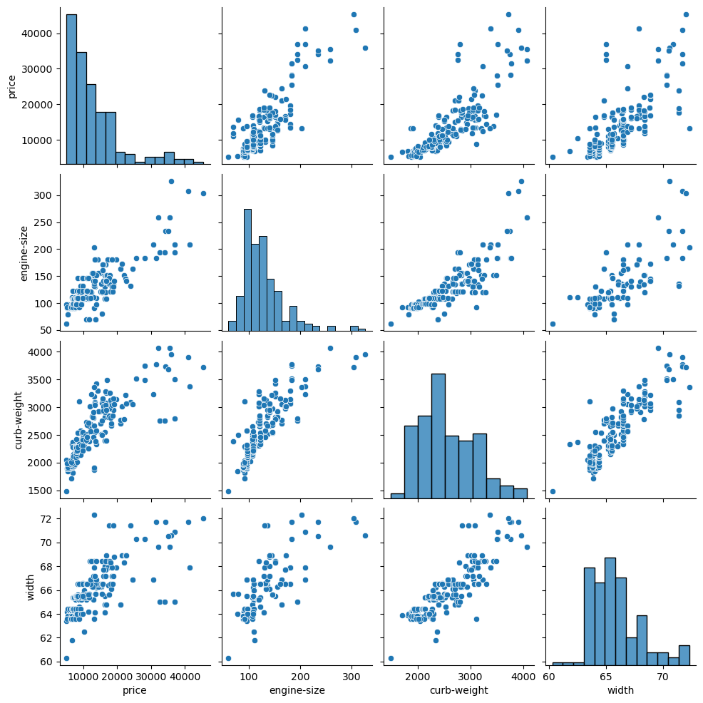

```python
sns.pairplot(df[['price', 'horsepower', 'engine-size', 'curb-weight', 'width']])
plt.show()
```